# MAUS TRATOS E ABUSO SEXUAL ROTINAS HRT RENATO FINAL

MAUS TRATOS NA INFÂNCIA

- **Introdução:**

A violência é considerada um grave problema de saúde pública no Brasil; crianças/adolescentes costumam ser alvo de maus-tratos que comprometem física e mentalmente a sua saúde.

A Organização Mundial de Saúde define maus-tratos como “toda forma de maus-tratos físicos e/ou emocionais, abuso sexual, abandono ou trato negligente, exploração comercial ou outro tipo, da qual resulte um dano real ou potencial para a saúde, sobrevivência, desenvolvimento ou dignidade da criança, no contexto de uma relação de responsabilidade, confiança ou poder”.

O diagnóstico de maus-tratos dificilmente se baseia em uma única lesão ou fator; na maioria dos casos, o Pediatra deve estar preparado para utilizar dados da história, do exame físico e exames complementares.

- **Mortalidade Infantil:**

Os dados do Sistema de Vigilância de Violências e Acidentes mostram que a violência se expressa de forma diferente entre os sexos. No masculino, as crianças na faixa etária entre 0 e 9 anos são as mais acometidas (33,6%), sendo a agressão física a forma mais frequente de violência; no sexo feminino, as adolescentes entre 10 e 19 anos são as principais vítimas (27,7%), sendo a violência psicológica, física e sexual os tipos mais prevalentes.

Cerca de 70% dos casos de violência contra criança/adolescente são cometidos pelos pais (pai e/ou mãe). Seguidamente, estão aqueles que se ocupam ou convivem com a vítima cotidianamente como tios, avós, irmãos e outros. Em apenas 3,3% dos casos, o agressor não é conhecido, tratando-se, na maioria das ocorrências, de situações de violência sexual.

- **Classificação:**

Maus-tratos, violência ou abuso infantil é definido como toda ação ou omissão por parte do adulto cuidador ou adolescente de mais idade, que na qualidade de responsável permanente ou temporário, possa resultar em dano de desenvolvimento físico, emocional, intelectual ou social da criança/adolescente; assim como, praticada fora de sua moradia, por pessoas de detêm a guarda temporária ou por estranhos. Cada um dos tipos de violência pode se manifestar de formas diferentes, não excludentes entre si.

**VIOLÊNCIA FÍSICA:**

Caracteriza-se pelo uso da força física de forma intencional, podendo ferir, provocar danos ou mesmo levar à morte da criança/adolescente, deixando ou não marcas evidentes. Trata-se de uma forma de violência bastante denunciada e frequente nos laudos periciais do Instituto Médico Legal (IML), por ser de mais fácil diagnóstico e a que mais mobiliza as pessoas para a denúncia. Acomete todas as faixas etárias da criança, porém, predomina nos menores de 3 anos de idade.

**DIAGNÓSTICO:**

Ao se avaliar uma criança/adolescente submetida a um trauma, a pergunta que se deve fazer sempre é: Trata-se de um trauma acidental ou intencional?”.

A suspeita de maus-tratos surge, geralmente, no momento em que se procede a anamnese, no decorrer do exame físico e mais raramente, de exames complementares.

- *ANAMNESE.*

Comportamento da vítima: muito agressivo ou apático; hiperativo ou depressivo; medo dos pais; alega agressão dos pais; relato de causas pouco viáveis às lesões; fugas de casa; faltas frequentes à escola.

Características da família: muitas vezes oculta às lesões, justificando-as de forma não convincente ou contraditórias; descreve a criança/adolescente como má e desobediente; abusa de álcool ou drogas ilícitas; defende uma disciplina severa; tem antecedentes de maus-tratos na família; pais separados; mães muito jovens.

- *EXAME FÍSICO*

**Aspecto geral:**

De maneira geral, deve-se levantar suspeitas de maus-tratos sempre que forem encontrados:

Lesões que não são compatíveis com a idade ou com o desenvolvimento psicomotor da criança/adolescente;

Lesões que não se justificam pelo acidente relatado;

Lesões em várias partes do corpo ou lesões bilaterais;

Lesões que envolvem partes usualmente cobertas do corpo;

Lesões em estágios diferentes de cicatrização ou cura.

Por ordem de frequência, as lesões por maus-tratos são mais comumente identificadas na pele e nas mucosas e, em seguida, no esqueleto, no sistema nervoso central (SNC) e nas estruturas torácicas e abdominais.

1. **Pele:**

As lesões de pele, quando intencionais, apresentam características próprias. É importante que a avaliação das lesões seja feita com detalhe, considerando tamanho, bordas, localização e cor das mesmas.

**Lesões de pele que sugerem lesão intencional:**

Hematomas: são os sinais mais frequentemente encontrados. Para datar o hematoma observar a coloração:

Cor vermelha ou azul (0-3dias); • Cor verde ou amarela (4-7dias); • Cor amarela ou marrom (8-26dias).

Escoriações: podem acompanhar os hematomas. As lesões com lacerações e as perfurocortantes podem requerer profilaxia do tétano;

Queimaduras: especial atenção quando são de extremidades e simétricas, principalmente, quando predominam em regiões de extensão, sugerindo algum esboço de defesa pelo agredido; atentar para áreas que envolvem áreas de flexão, região genital e de nádegas. O encontro de linha regular até onde a região do corpo foi mergulhada no líquido quente são características de maus-tratos;

Mordeduras: as marcas costumam ser evidentes. Quando múltiplas, são forte indício de tortura e, se encontradas em região de pescoço, mamas ou próximas à região genital, deve ser pesquisado abuso sexual. Mordeduras requerem o uso de antibioticoprofilaxia, com Amoxicilina com Clavulanato, na dose de 50mg/kg/dia, a cada 12 horas, por 5 dias;

Lesões circulares em pescoço, punhos ou tornozelos são indícios de tentativa de enforcamento ou de que a criança/adolescente está sendo mantida amarrada.

**Algumas patologias que simulam lesões de pele:**

Manchas mongólicas;

Leucemia aguda;

Lesões purpúricas associadas a coagulopatias e a distúrbios vasculares agudos (consequências de Púrpura de Henoch-Schönlein);

Púrpura Trombocitopênica Idiopática;

Fitofotodermatose.

2. **Fraturas:**

Podem aparecer em até 40% das crianças com abuso físico e suas características são fundamentais para o diagnóstico. Os ossos longos como fêmur, tíbia, antebraço e úmero requerem uma maior força para sofrerem fraturas, o que dificilmente ocorrem em quedas de pequena altura. Até os 2 anos de idade, as fraturas acidentais são incomuns, principalmente as fraturas dos membros superiores em crianças abaixo de 4 meses e de membros inferiores em crianças que não andam.

**Evolução de fratura óssea:**

Edema e dor: 0-10dias; • Formação periosteal: 7-14dias; • Calo mole: 14-21dias; • Calo duro: 21-42dias.

**Alguns tipos de fraturas encontradas em lesões intencionais:**

Fraturas múltiplas, bilaterais ou em diferentes estágios de consolidação;

Fraturas não-compatíveis com o desenvolvimento motor;

Fraturas dos arcos costais;

Fraturas de crânio: múltiplas, complexas, bilaterais, que cruzam a linha média;

Fraturas de vértebras sem história de trauma acidental de alta energia (atropelamento, colisões automobilísticas, quedas de grande altura);

Fraturas de coluna vertebral;

Fratura de mandíbula sem outras lesões que a justifiquem.

**Algumas patologias simulam lesões de fraturas músculo-esqueléticas:**

Traumas de alta energia (atropelamento, colisões automobilísticas, quedas de grande altura);

Fraturas unilaterais de crânio em bebês a partir do quinto ou sexto mês que caem da cama ou do trocador;

Lesões de cabeça e membros em quedas de bicicleta ou outros veículos não-motorizados usados sem proteção;

Lesões de costelas (resultado de reanimação cardiorrespiratória);

Algumas doenças mais raras: Osteogênese imperfeita, Raquitismo.

3. **Cabeça/Sistema Nervoso Central:**

A frequência de lesão acidental na cabeça de crianças, de modo superficial, até o segundo ano de vida é relativamente alta; entretanto, quedas acidentais da própria altura de crianças com menos de 1,20 metros de altura muito raramente causam dano neurológico.

**Lesões na cabeça que sugerem trauma intencional:**

■ olhos: com frequência, há o aparecimento de edemas e hematomas; algumas vezes, pode haver comprometimento de cristalino ou mesmo retina, podendo levar à amaurose;

■ orelhas: podem aparecer deformidades por traumas repetitivos;

■ boca: as lesões na cavidade oral são frequentes; podem aparecer também alterações dos dentes (amolecimento, escurecimento).

Nos casos de Traumatismo Crânio Encefálico (TCE) deve-se solicitar Tomografia Computadorizada de crânio.

4. **Abdome e Tórax:**

O mecanismo pode ser agressão direta, geralmente, pelo punho ou por brusca desaceleração após a criança/adolescente ser empurrado.

**Regiões de lesão que sugerem lesão intencional:**

Abdome: em traumas fechados (socos ou pontapés), podem haver perfurações de vísceras ocas ou rupturas de fígado ou baço, podendo levar a um quadro característico de abdome agudo;

Tórax: pode haver hemotórax ou pneumotórax secundários às fraturas de costelas (bastante raras em traumas acidentais).

- EXAMES COMPLEMANTARES:

**Os exames complementares devem ser direcionados pelo quadro clínico:**

| Hematológicos | Hemograma, Coagulograma |
| --- | --- |
| Bioquímicos | CPK, Amilase, Enzimas hepáticas, Eletrólitos, Intoxicação exógena |
| Urinários | Urina tipo I, Intoxicação exógena |
| Imagem | Radiografia Simples + até 2 anos de idade e em crianças que não se comunicam: fazer corpo inteiro + maiores de 2 anos de idade: com base na anamnese e no exame físico |
|  | Ultrassonografia: abdômen e fontanela, quando o quadro clínico sugerir algum agravo* |
|  | Tomografia Computadorizada: crânio, tórax e abdômen, quando o quadro clínico sugerir algum agravo* |
|  | Fundo de olho: quando sinais de hemorragia intracraniana |

Agravo: exame neurológico alterado, como diminuição do nível de consciência, irritabilidade, diminuição da aceitação alimentar, vômitos, convulsões, alteração da respiração, coma ou postura em opistótono.

OBS: SÍNDROME DO BEBÊ SACUDIDO (SBS)

A aplicação de sacudidas violentas na criança com até 2 anos de vida é uma das formas mais graves de agressão à criança pequena, pois pode levar à lesão cerebral, podendo deixar sequelas, na dependência da força e intensidade aplicadas.

As forças de aceleração e desaceleração, aliadas às de rotação, fazem com que a massa encefálica do bebê se movimente bruscamente, com velocidades diferentes a depender de sua estrutura, volume, peso e fixação e se choca com a calota craniana, provocando vários tipos de lesões vasculares e teciduais por contusão, rompimento ou cisalhamento.

O tamanho da cabeça relativamente grande em relação ao corpo, a anatomia da coluna cervical e do forame magno, a fraqueza da musculatura cervical e o menor grau de mielinização fazem com que possa haver lesão de massa encefálica após o mecanismo descrito, sem que se evidenciem sinais externos evidentes de trauma. A SBS pode desencadear desde microemorragias do SNC até hemorragias maciças e morte, sem que haja fratura de calota craniana.

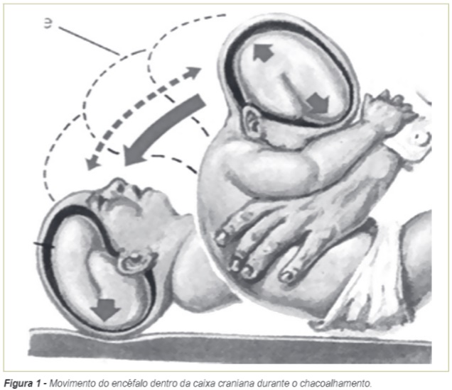

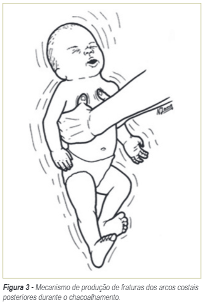

A sintomatologia nem sempre é evidente, mas deve-se pensar nela sempre que uma criança com menos de 2 anos de idade apresentar sinais de comprometimento de SNC, sem existir sinais infecciosos ou histórico de convulsões graves. Os sintomas vão desde alterações do nível de consciência, irritabilidade ou sonolência, convulsões, déficits motores, problemas respiratórios, coma e, alguns casos, morte.

A tríade clássica é composta de Encefalopatia aguda, Hematoma subdural (consequente à ruptura das veias pontes no espaço subdural) e Hemorragia Retiniana (crianças com TCE leve ou moderado, como os consequentes à queda do berço, ou até mesmo em traumas acidentais graves, como acidentes automobilísticos, dificilmente apresentam hemorragia retiniana).

**Algumas características são mais presentes na SBS, entretanto não são patognomônicas:**

Lesões esqueléticas: aparecem em até 50% dos casos (fratura em arco posterior da costela reforça o diagnóstico da síndrome);

Lesões oculares: lesão em ambos os olhos, sem que haja comprometimento do nariz. Presença de estrabismo que apareça de forma aguda, sem histórico anterior de desvio ou déficits de visão importante ou sem lesão.

Estima-se que menos de 20% dos pacientes com SBS têm evolução favorável; cerca de 30% morre rapidamente. Muitos sobreviventes apresentam sequelas neurológicas (lesões encefálicas, convulsões e lesões da coluna vertebral e medula espinal) ou oculares (hemorragias oculares, cegueira) importantes.

- **Violência Psicológica:**

Caracteriza-se pela submissão da criança/adolescente a ações verbais ou atitudes que visem à humilhação, à indiferença, à rejeição, à ameaça e à responsabilização excessiva que possam levar danos a seu desenvolvimento, tanto na área psíquica como na afetiva, moral e social. É uma forma de violência difícil de ser conceituada e diagnosticada, entretanto, costuma estar presente concomitantemente aos demais tipos de abuso. É importante o acompanhamento psicológico, evitando problemas futuros de adequação social.

Comportamento da vítima: comportamentos infantis; enurese noturna; comportamentos extremos de timidez ou agressividade; distúrbios do sono; isolamento; baixo conceito de si próprio; abatimento profundo; autoflagelação; ideia e tentativa de suicídio.

Características da família: tem expectativas irreais sobre a criança/adolescente; rejeita; aterroriza; ignora; desqualifica; exige em demasia; descreve a criança/adolescente como má/diferente das demais; filhos não desejados, mães adolescentes sem suporte psicossocial ou em situação de isolamento, falta de apoio familiar e de recursos; antecedentes de violência familiar e ruptura familiar; antecedentes psiquiátricos.

**Formas de maus-tratos psicológicos:**

Castigos excessivos, recriminações, ameaças;

Rejeição ou desqualificação da criança/adolescente;

Responsabilidades excessivas para a idade;

Isolamento devido a mudanças frequentes ou a proibições de convívio social;

Clima de violência entre os pais e uso da criança como objeto de descarga emocional;

OBS<sub>01</sub>: BULLYING: O termo *Bullying* compreende todas as atitudes agressivas, intencionais e repetidas, que ocorrem sem motivação evidente, adotadas por um ou mais indivíduos contra outro(s), causando dor e angústia. Pode ser em consequência da diferença de idade, tamanho, desenvolvimento físico ou emocional, dentre outros. Convencionou-se não considerar *bullying* os atos isolados, executados eventualmente, mas somente quando tais atos se tornam repetitivos, contando a partir da terceira vez.

OBS<sub>02</sub>: CYBERBULLYING: Violência praticada com o uso da tecnologia da informática e *internet.* Tem o potencial de ser replicado muitas vezes em curto período de tempo; é considerado *bullying*, mesmo quando praticado uma única vez.

- **Negligência:**

Caracteriza-se por atos ou atitudes de omissão, de forma crônica, com prejuízo à higiene, à nutrição, à saúde, à educação, à proteção e/ou ao afeto da criança/adolescente, apresentando-se em vários aspectos e níveis de gravidade, sendo o abandono o grau máximo. Dois critérios são necessários para caracterizar a negligência: a cronicidade e a omissão. Pode apresentar-se de forma intencional ou não.

Apesar de frequente, a negligência apresenta grande dificuldade para ser definida e identificada, pois não há padrão para diferenciar o que é inabilidade ou impossibilidade e o que é falta de vontade dos pais ou responsáveis para prover as crianças/adolescentes das necessidades mínimas aceitáveis.

**Comportamento da vítima:** comportamentos extremos de hiper ou hipoatividade; contínuas faltas ou atrasos à escola/ao médico; comportamentos infantis ou depressivos; dificuldade na aprendizagem.

**Características da família**: é apática e passiva, não se importando muito com a situação da criança/adolescente; tem baixo autoestima e severo desleixo com higiene; é despreocupada em resolver as necessidades de atenção da criança/adolescente.

O processo de recuperação terá maior probabilidade de ocorrer com o atendimento precoce e adequado, que inclua não só o tratamento dos agravos físicos e emocionais, como também a assistência familiar.

- **Violência Sexual:**

Caracteriza-se pelo uso da criança/adolescente para gratificação sexual e inclui desde carícias, manipulação de genitália, mama ou ânus, voyeurismo, pornografia, exibicionismo, exploração sexual, até o ato sexual com penetração oral, anal ou vaginal. Engloba ainda a situação de exploração sexual visando a lucros como prostituição e pornografia.

A violência sexual destaca-se entre as diferentes formas de violência pelo forte conteúdo moral. O uso da violência física associada à violência sexual está presente apenas em uma pequena parte dos casos identificados. A maioria das situações de violência sexual é praticada por pessoas próximas (o companheiro da mãe aparece como maior agressor, seguido em segundo lugar pelo pai, depois o tio, o avô e parente próximo), que contam com a confiança da criança, e ocorrem de maneira gradual e progressiva por longos períodos de tempo. As sensações físicas do contato sexual, geralmente, são prazerosas e é bastante comum que crianças estimuladas sexualmente por adultos busquem a repetição desses estímulos, seja com adultos, seja com outras crianças; além de poder haver uma interpretação positiva da criança como uma forma de atenção ou de “dedicação” que talvez, até então, não conhecia.

O Código Penal Brasileiro, no seu Artigo 224, determina que a violência sexual é sempre presumida em menores de 14 anos, deficientes mentais ou quando a vítima não puder, por qualquer outra causa, oferecer resistência.

**Comportamento da vítima: comportamento sexual inadequado para a idade;** não confia em adultos; fugas de casa; regressão a estado de desenvolvimento anterior; brincadeiras sexuais agressivas; comportamento promíscuo; vergonha excessiva e alegações de abusos; ideias e tentativa de suicídio; autoflagelação.

**Características da família: oculta frequentemente o abuso;** é muito possessiva, negando à criança/adolescente contatos sociais normais; acusa a criança/adolescente de promiscuidade, sedução sexual e de ter atividade sexual fora de casa; crê que o contato sexual é forma de amor familiar; alega outro agressor para proteger membro da família.

De maneira esquemática, podem-se dividir as situações de violência sexual em agudas e crônicas:

5. **Violência Aguda:**

Corresponde, em sua grande maioria, aos “assaltos sexuais” com ocorrência, principalmente, no espaço público. São mais frequentes no percurso de trânsito entre casa-escola/trabalho/lazer. As ameaças à vida ou à integridade física são bastante explícitas e estão associadas à violência física e acometem, principalmente, adolescentes adultas. O agressor, geralmente, é desconhecido, sem vinculação com a vítima. O atendimento a esse tipo de situação deve ser realizado o mais rápido possível em serviço de urgência, pela necessidade de avaliação imediata e tratamento de eventuais lesões físicas, e pelos prazos definidos para o início das profilaxias contra Infecção Sexualmente Transmissível (IST) e gestação indesejada.

6. **Violência Crônica:**

Ocorre por períodos de tempo mais extensos, de maneira progressiva, cometidas contra ambos os sexos, principalmente por pessoas próximas, que contam com a confiança das crianças e das famílias. As ameaças são, geralmente, mais veladas, e o uso de violência física nem sempre está presente. Existe a possibilidade de contaminação por IST ou gestação, mas lacerações e lesões físicas graves são pouco frequentes.

- **Atendimento:**

A notificação criminal (boletim de ocorrência - BO) de crimes sexuais é um direito exclusivo da vítima ou de seu responsável legal, exceto quando o agressor possui o poder familiar sobre a vítima ou nenhum outro familiar quiser fazer a denúncia, caso em que o BO pode ser feito pela equipe de saúde, de acordo com o Artigo 245 do Estatuto da Criança e do Adolescente. No seguimento de casos de violência sexual, o Conselho Tutelar (CT) deve ser acionado imediatamente; este encaminhará a vítima ao Departamento de Polícia (DP) para fazer um BO e posteriormente, é realizado o laudo pericial pelo IML. Deve-se atentar com falsas denúncias de abuso sexual, principalmente entre casais em situação de litígio.

- **Diagnóstico:**

**Annamese:**

Ao atender uma situação em que haja suspeita de violência sexual, o profissional deve evitar fazer pré-julgamentos ou emitir diagnósticos precipitados. O profissional deve portar-se de modo atencioso e acolhedor. O registro deve ser o mais próximo possível da história relatada, evitando-se traduzir para termos técnicos. Importante a identificação dos diferentes relatores, afim de permitir a análise posterior de possíveis contradições e omissões. Deve-se anotar as observações sobre o comportamento dos envolvidos antes, durante e depois da anamnese. Quando houver o relato espontâneo da criança, seu depoimento deve merecer toda a credibilidade, pois dificilmente ela seria capaz de elaborar uma falsa história de abuso sexual.

**Exame Físico:**

O exame físico deve ser sempre realizado na presença de um dos responsáveis e esclarecido previamente à criança/adolescente sobre os procedimentos. Observar, de maneira cuidadosa e abrangente, há presença de lesões indicativas de violência física. Na grande maioria dos casos não se constatam lesões físicas evidentes e a gravidade das lesões internas nem sempre está correlacionada às lesões visíveis externamente. Os sinais de irritação peritoneal podem ser difíceis de ser avaliados em crianças muito pequenas, sendo necessária a complementação diagnóstica com métodos de imagem.

As áreas usualmente envolvidas em atividades sexuais são boca, mamas, genitais, região perineal, nádegas e ânus.

Sinais de alerta para abuso sexual:

Lesões em região genital;

Hematomas ou lacerações em região próxima ou em área genital;

Dilatação anal ou uretral, ou rompimento de hímen;

Lesões como equimoses, hematomas, mordidas ou lacerações em mamas, pescoço, parte interna e/ou superior de coxas, baixo abdômen e/ou região do períneo;

Sangramento vaginal em crianças pré-púberes, ou anal, acompanhados de dor;

Lesões por IST.

- **Exames Complementares:**

Devem ser colhidas, na urgência, secreções vaginais e anais e sorologias para as principais IST. Sempre que possível, coletar material que ajude a comprovar o abuso: pesquisa de sêmen, sangue e células epiteliais pode ser feita quando o abuso ocorreu há menos de 72 horas.

**Solicitar exames no primeiro dia da consulta e programar os seus controles:**

Sorologias: VDRL, controle com 45 a 90 dias;

Hepatite B e C, controle com 180 dias;

Anti-HIV, controle com 90 e 180 dias;

Cultura de secreção vaginal e endocervical;

Hemograma completo e transaminases após os 28 dias de uso dos antirretrovirais.

Nos casos em que medicamentos antirretrovirais forem indicados, é necessário o monitoramento da função renal e hepática.

- **Profilaxia:**

Sempre que possível, solicitar avaliação conjunta do profissional ginecologista. Quando da alta hospitalar, a criança/adolescente deverá ser encaminhada para o Centro de Saúde de referência de IST/AIDS mais próximo, a fim de adquirir o restante das medicações antirretrovirais e fazer o acompanhamento

**Profilaxia de emergência da gestação:**

A profilaxia de emergência da gestação é realizada em pacientes que já menstruam e indicada nas primeiras 72 horas após o coito suspeito. A dosagem recomendada é de 2 comprimidos de levonorgestrel 0,75mg, via oral, em uma única tomada.

**Profilaxia das IST não virais:**

| Sífilis | Penicilina Benzatina | 50.000U/Kg, IM, dose única (dose máxima = 2.400.00U) OU |
| --- | --- | --- |
|  | Eritromicina | 50mg/Kg/dia (dose máxima = 2g/dia), VO, 6/6horas, por 15 dias |
| Cancro Mole | Azitromicina | 30mg/Kg, VO, dose única (dose máxima 1.500mg) |
| Gonorreia | Ceftriaxona | 250mg, IM, dose única |
| Tricomoníase | Metronidazol | 15mg/Kg/dia (dose máxima = 750mg/dia), VO, 8/8horas, por 7 dias |

**Profilaxia à Hepatite B:**

Pacientes que não foram vacinadas contra Hepatite B ou com situação vacinal desconhecida, devem receber imunoglobulina específica, além da complementação do esquema vacinal. A dose recomendada da imunoglobulina anti-hepatite B é de 0,06mL/kg, IM, em dose única.

**Quimioprofilaxia antirretroviral:**

As medicações antirretrovirais devem ser utilizadas criteriosamente, pois devem ser tomadas por um período relativamente longo (28 dias) e não são isentas de efeitos colaterais.

**Os critérios para a administração de antirretrovirais incluem:**

A forma de exposição: somente em casos com penetração anal ou vaginal;

O intervalo entre a exposição e o início da tomada da medicação deve ser inferior a 72 horas;

O status sorológico do agressor: sabidamente doente ou quando conhecido.

O esquema recomendado para as crianças inclui dois Inibidores Nucleosídeos da Transcriptases Reversas e um Inibidor da Protease/r, sendo composto por Zidovudina (AZT) + Lamivudina (3TC) + Lopinavir-R (LPV/R).

**As doses recomendadas para crianças/adolescentes com peso inferior ou igual a 45kg são:**

| **MEDICAÇÃO** | **APRESENTAÇÃO** | **POSOLOGIA** |
| --- | --- | --- |
| AZT | 300mg/150mg | 1 comprimido a cada 12 horas |
| 3TC | Solução oral 10mg/ml | 4mg/kg/dose a cada 12 horas (dose máxima: 150mg de 12/12horas) |
| LPV/R | Solução oral 80mg Solução oral 20mg/ml Comprimidos 200mg | < 2anos: 300mg/m<sup>2</sup> de 12/12horas > 2anos: 230mg/m<sup>2</sup> de 12/12horas (dose máxima 200mg de 12/12horas Adolescentes: 400mg 12/12horas |

Superfície Corpórea (m<sup>2</sup>): {(4 x Peso (kg) +7} / {Peso (kg) + 90}

- **DIAGNÓSTICO DIFERENCIAL:**

Distúrbios hormonais;

Puberdade precoce;

Fissuras anais por obstipação;

Corpo estranho;

Vulvovaginites inespecíficas.

- **Formas Peculiares De Violência:**

**Síndrome de Munchausen por Procuração/por Transferência (Smt):**

Caracteriza-se pela situação na qual o paciente é trazido para cuidados médicos, mas os sinais/sintomas que apresentam são inventados, simulados ou provocados por seus responsáveis; podem também ocorrer acréscimos de sintomas ou o aumento da frequência de um evento que ocorre espontaneamente. Essa prática impõe sofrimentos físicos ao paciente, como a exigência de exames complementares desnecessários, o uso de medicamentos ou ingestão forçada de substâncias, além de poder provocar danos psicológicos pelas múltiplas consultas e internações sem motivo.

Os “agressores”, normalmente a mãe (85 a 95% dos casos), não são agressivos nem negligentes, ao contrário das outras formas de violência.

É importante não confundir SMT com situações que podemos chamar de “por conveniência”, nas quais a doença é inventada ou simulada de modo fraudulento para obter vantagens, como afastamento do trabalho, recebimento do valor de um seguro.

Há dificuldade na avaliação de incidência, devido dificuldade do diagnóstico. Sabe-se que ambos os sexos sofrem esse tipo de agressão na mesma proporção e a maior prevalência dá-se antes dos 5 anos de idade.

As queixas referentes ao SNC são as mais comuns e representam 45% do total e incluem convulsões, apneia e depressão. As queixas gastrintestinais também são habituais e observadas em aproximadamente 10% dos casos. Os vômitos podem ser induzidos mecanicamente ou com o auxílio de fármacos. Algumas vezes, os vômitos podem ter aspecto fecaloide, simulado com a adição de fezes ao vômito. As diarreias podem ser causadas pela administração de laxativos. As erupções cutâneas, observadas em 10% dos casos, podem ser induzidas pela aplicação de substâncias cáusticas e tinturas na pele ou por atrito e escoriações. As queixas de febre são referidas em 10% das ocorrências. A elevação da temperatura pode ser por aquecimento do termômetro, aquecimento da própria criança ou por injeção de substâncias pirógenas. Os sangramentos são também queixas comuns (hematúria é a mais frequente). Podem ser simulados com sangue de outra pessoa ou com substâncias coloridas que aparentem ser sangue e/ou serem induzidos por administração de medicamentos anticoagulantes.

A partir do aumento de idade, há uma tendência de que a criança passe a participar da fraude, associando-se ao responsável como cúmplice e, a partir da adolescência, pode tornar portadora da “Síndrome de Munchausen *by self*”, em que os sintomas passam a ser inventados, simulados ou produzidos por ela mesma.

O tempo para a realização do diagnóstico varia de 3 a 6 meses e na maioria das vezes (75%-95%), os sinais e sintomas podem persistir com a criança internada, já que o responsável permanece ao lado dela.

**Situações de alerta para diagnóstico de SMP:**

Doença prolongada inexplicável;

Quadros repetidos, cíclicos ou contínuos, difíceis de caracterizar, com história, evolução, resultados de exames e respostas terapêuticas incomuns;

Sintomas que parecem impróprios e incongruentes, que só ocorrem na presença da mãe e que predominam à noite, quando a supervisão por outras pessoas é menor;

O resultado do tratamento é referido como ineficaz ou não é tolerado ou deixa de funcionar após algum tempo;

A doença piora quando se cogita a alta hospitalar;

Inconsistência do tipo “sangra, mas não causa anemia”, ou febre sem aumento concomitante da frequência cardíaca e respiratória;

Sinais e sintomas desaparecem ou melhoram quando o agressor se afasta da criança.

- **Autoagressão:**

Caracteriza-se pela violência do indivíduo contra ele próprio, representa uma ameaça grave à vida, sendo necessário o reconhecimento precoce dos sinais e condutas de risco, comuns em crianças/adolescentes portadores de distúrbios de comportamento e doenças psiquiátricas, mas que nem sempre apresentam manifestações evidentes. Pode ser considerada uma sequela das vítimas de maus-tratos, que usam as lesões como forma de chamar atenção para si ou para demonstrar o descaso com sua existência. Em criança/adolescente, a autoagressão mostra-se por meio de atividades de risco, procura direta de formas de lesar a si mesmo (*cutting*) e suicídio (grau máximo de autoagressão). Na maioria dos casos que chegam a óbito, podem-se encontrar, no histórico, atitudes de comportamento de risco e, geralmente, relato de uma ou mais tentativas anteriores de suicídio.

- **Roteiro De Atendimento:**

Os maus-tratos, o abuso ou qualquer tipo de violência doméstica devem ser reconhecidos como enfermidades, pois são assim identificados no Código Internacional de Doenças, e corresponde a categoria T74.0 – Síndrome de maus-tratos.

Quando há um caso suspeito/confirmado de violência é importante dar atendimento humanizado à vítima/família, em ambiente adequado. Se possível, a criança/adolescente deve ser ouvida sozinha, com respeito e privacidade, utilizando as mesmas palavras que a vítima e não fazendo promessas que não se possa cumprir, nem prometer guardar segredo antes de saber o que será revelado.

Ressalta-se que a criança/adolescente tem direito a sigilo e à confidencialidade das informações. No entanto, isso deve ser rompido nas situações previstas por lei, como nos casos de violência ou de risco à vida, sendo, portanto, necessária a notificação ao CT.

Se o agressor é alguém da família, não é conveniente informá-lo imediatamente. Nesse caso, deve-se entrar em contato, de modo estratégico, com membros não agressores, de preferência com indicação da criança. Orientar sobre a importância do tratamento para o agressor, se ele for da família.

Quando há um caso suspeito/confirmado de violência há necessidade de se preencher a Ficha de Notificação (FN) a ser encaminhada também à Vigilância Epidemiológica. Também deve-se verificar se há lesões graves e/ou risco de vitimização durante anamnese e exame físico. Após o atendimento médico, a família/o responsável pela criança/adolescente deverá ser orientado a lavrar BO em uma DP (da mulher ou da infância e juventude), que deverá encaminhar o paciente para exames e coleta de provas forenses pelos peritos do IML. Se possível, a criança/adolescente deve ser acompanhado pelo Técnico de Enfermagem ou Agente de Serviço Social ou outro profissional disponível.

Quando a criança/adolescente em situação de violência apresentar lesões leves e não for detectado risco de revitimização com o seu retorno para a sua moradia, deve-se notificar o CT da região de moradia do paciente. A notificação pode ser mediante relatório institucional elaborado por um membro da equipe interprofissional. Considera-se como risco de revitimização o fato de o agressor não ser controlável ou a família ou cuidadores do paciente não parecerem competentes e capazes de proteger a criança/adolescente.

Na presença de lesões graves ou quando o retorno da criança/adolescente para sua moradia puder resultar em revitimização, ela deve ser internada, para que permaneça sob a proteção da instituição hospitalar, devendo-se notificar o CT e a Vara da Infância e Juventude (VIJ) da região de moradia do paciente. Tal notificação precisa ser realizada mediante ofício contendo relatório da equipe multiprofissional. A alta hospitalar dependerá de critérios clínicos e da decisão judicial. Quando há lesão grave e/ou risco de revitimização, caso não haja restauração do vínculo familiar, haverá decisão judicial quanto à guarda da criança.

Quando o CT recebe a notificação, primeiro apura-se a veracidade da situação através de conversas com a família e visita domiciliar; realiza um diagnóstico da situação de cada família e posteriormente poderá acionar os serviços da comunidade em que aquela família mora para ajudar em seus problemas (necessidade de apoio psicológico, inserção na escola, vaga em creche e outras demandas). Apenas nos casos mais graves ou em que o Conselho esgote as tentativas para a mudança daquela situação, o próprio Conselho irá acionar a VIJ ou o Ministério Público.

Independentemente do tipo de violência e gravidade, após a alta hospitalar, a criança/adolescente, assim como suas famílias, deverão ser encaminhadas para acompanhamento ambulatorial/psicossocial por equipe interprofissional.

- **Observação:**

**Em caso de Violência Física/Sexual:**

**Notificação: ao detectar casos de violência, deve-se preencher e dar andamento às 4 vias da FN:**

Anexar 01 via ao prontuário;

Encaminhar a criança, juntamente com 01 via, ao plantão policial do hospital, que as encaminhará à DP mais próxima ou à Delegacia Especial de Proteção à Criança e ao Adolescente (DPCA).

Encaminhar 02 vias ao Serviço Social (SS) ou ao Programa de Prevenção e Atendimento às Vítimas de Violência (PAV) para sua intervenção e posterior encaminhamento das fichas ao CT e Sistema de Informação da SES/DF.

**Em caso de Negligência/Violência Psicológica:**

**Notificação: ao detectar casos de violência, deve-se preencher e dar andamento às 4 vias da FN:**

Anexar 01 via ao prontuário; somente em casos graves, encaminhar para DP;

Encaminhar 02 vias ao SS ou ao PAV para sua intervenção e posterior encaminhamento das fichas ao CT e Sistema de Informação da SES/DF.

- **Referências:**

Barnnwart TH, Brino RF. *Dificuldades enfrentadas para identificar e notificar casos de maus-tratos contra crianças e/ou adolescentes sob a óptica de médicos pediatras.* Revista Paulista de Pediatria. São Paulo.2011;29(2)138-45.

Fernandes CLC, Curra LCD. *Violência intrafamiliar e atenção primária à saúde*. IN: Sociedade Brasileira de Medicina de Família e Comunidade; Castro Filho ED, Anderson MIP, organizadores. PROMEF Programa de Atualização em Medicina de Família e Comunidade: Ciclo 2. Porto Alegre: Artmed Panamericana; 2007. p. 9-31. (Sistema de Educação Continuada a Distância, v. 1).

Ferreira AL *et al*. *Guia de atuação frente a maus-tratos na infância e na adolescência*. IN: Sociedade Brasileira de Pediatria. 2nd. Rio de Janeiro. 2001.

Forlin E, Pfeiffer L. *Maus-tratos na infância e adolescência*. IN: Sociedade Brasileira de Traumatologia e Ortopedia. PROATO Programa de Atualização em Traumatologia e Ortopedia: Ciclo 1. Porto Alegre: Artmed Panamericana; 2005. p. 125-61. (Sistema de Educação Continuada a Distância, v. 1).

Hirschheimer MR. *Abuso físico e sexual e a criança na unidade de terapia intensiva*. IN: Sociedade Brasileira de Pediatria. PROTIPED Programa de Atualização em Medicina Intensiva Pediátrica: Ciclo 4. Porto Alegre: Artmed Panamericana; 2012. p. 71-133. (Sistema de Educação Continuada a Distância, v. 2).

Marques RM, Teixeira AMS, Barbosa GB. *Violência sexual: abordagem no departamento de emergência*. IN: Sociedade Brasileira de Clínica Médica; Lopes AC, Tallo FS, Lopes RD, Vendrame LS, organizadores. PROURGEM Programa de Atualização em Medicina de Urgência e Emergência: Ciclo 10. Porto Alegre: Artmed Panamericana; 2017. p. 129-50. (Sistema de Educação Continuada a Distância, v. 4).

Moriya RM, Canheu AC, Moryia LK. *Atendimento inicial ao traumatismo cranioencefálico em crianças.* IN: Sociedade Brasileira de Pediatria; Oliveira Filho EA, Nobrega M, organizadores. PROPED Programa de Atualização em Terapêutica Pediátrica: Ciclo 2. Porto Alegre: Artmed Panamericana; 2016. p. 9-68. (Sistema de Educação Continuada a Distância, v. 4).

Pfeiffer L. *Assistência a crianças e adolescentes vítimas de violência sexual.* IN: Sociedade Brasileira de Pediatria; Oliveira Filho EA, Nobrega M, organizadores. PROPED Programa de Atualização em Terapêutica Pediátrica: Ciclo 2. Porto Alegre: Artmed Panamericana; 2015. p. 63-109. (Sistema de Educação Continuada a Distância, v. 2).

Secretaria de Estado de Saúde do Distrito Federal – Manual para atendimento às vítimas de violência na rede de saúde pública do DF. 2nd. Brasília.2009. p. 9-66.

Uhmann A, Kaufman A, Garcia CD, Lipinski RW. *Violência e saúde de adolescentes e jovens – como o pediatra deve proceder.* IN: Sociedade Brasileira de Pediatria; AZEVEDO AEBI, organizadores. Documento Científico – Departamento Científico de Adolescência. 2018. p. 1-12.

Responsável pela elaboração da rotina: Dr. Renato Resende Mundim